# HW9_94109324

Mohammad Roghani

Ordibehesht 27, 1397 AP

# Q1

در این سوال همان طور که خواسته شد به ازای هر مدت زمان و هر بخش بیشترین رکورد سود سالانه را از طریق تفاوت دو مقدار close و open برای شرکت ها به دست آوردم و در جدول خروجی داده شده است

```r
library(dplyr)
library(stringr)
library(readr)
library(lubridate)
best_company = data.frame()
all_symbols = list.files('class_data/stock_dfs/') %>% str_replace('.csv', '')
address = list.files('class_data/stock_dfs/', full.names = TRUE)
fs = length(address)
files = list()
for(i in 1:fs) files[[i]] = read.csv(address[i])
for (i in 1:fs){
  temp = files[[i]] %>% select(Date, Close, Open) %>% mutate(year = year(Date)) %>% mutate(year2 = (year - first(year)) %/% 2, year5 = (year - first(year)) %/% 5)
  one_year = temp %>% group_by(year) %>% summarise(income = last(Close) - first(Open)) %>% top_n(income, n = 1)
  two_years = temp %>% group_by(year2) %>% summarise(income = last(Close) - first(Open)) %>% top_n(income, n = 1)
  five_years = temp %>% group_by(year5) %>% summarise(income = last(Close) - first(Open)) %>% top_n(income, n = 1)
  best_company = rbind(best_company, data.frame(all_symbols[i], one_year, two_years, five_years))
}
colnames(best_company)[1] = 'Symbol'
colnames(best_company)[5] = 'income2'
colnames(best_company)[7] = 'income5'
constituents = read.csv('class_data/constituents.csv')
best_company = best_company %>% inner_join(constituents, by = 'Symbol')
best_company %>% group_by(Sector) %>% filter(income == max(income)) %>% select(Sector, Symbol, income)
```

```
## # A tibble: 11 x 3
## # Groups:   Sector [11]
##    Sector                     Symbol income
##    <fct>                      <chr>   <dbl>
##  1 Consumer Discretionary     AMZN    363.
##  2 Industrials                AYI      92.3
##  3 Financials                 CME     170.
##  4 Utilities                  DUK      41.7
##  5 Real Estate                EQIX    103.
##  6 Information Technology     GOOG    401.
##  7 Health Care                ISRG    226.
##  8 Materials                  MLM      86.9
##  9 Energy                     PXD      74.6
## 10 Consumer Staples           STZ      44.3
## 11 Telecommunication Services T        11.3
```

```r
best_company %>% group_by(Sector) %>% filter(income2 == max(income2))%>% select(Sector, Symbol, income2)
```

```
## # A tibble: 11 x 3
## # Groups:   Sector [11]
##    Sector                     Symbol income2
##    <fct>                      <chr>    <dbl>
##  1 Consumer Discretionary     AMZN     277.
##  2 Financials                 CME      317.
##  3 Real Estate                EQIX     125.
##  4 Utilities                  ETR       50.4
##  5 Information Technology     GOOG     468.
##  6 Industrials                GWW       90.0
##  7 Consumer Staples           MNST      81.1
##  8 Materials                  PPG      104.
##  9 Energy                     PXD       92.2
## 10 Health Care                REGN     267.
## 11 Telecommunication Services T         17.1
```

```r
best_company %>% group_by(Sector) %>% filter(income5 == max(income5))%>% select(Sector, Symbol, income5)
```

```
## # A tibble: 11 x 3
## # Groups:   Sector [11]
##    Sector                     Symbol income5
##    <fct>                      <chr>    <dbl>
##  1 Industrials                AYI      176.
##  2 Consumer Discretionary     AZO      460.
##  3 Financials                 CME      471.
##  4 Consumer Staples           COST      82.6
##  5 Utilities                  DUK       66.3
##  6 Real Estate                EQIX     129.
##  7 Information Technology     GOOG     812.
##  8 Energy                     PXD       99.5
##  9 Health Care                REGN     386.
## 10 Materials                  SHW      201.
## 11 Telecommunication Services VZ        13.4
```

# Q2

باتوجه به مقدار p-value در t-test و نمودار رسم شده به نظر میرسد که ۱۳ام ماه تاثیری در سود یا زیان ندارد.

```r
library(highcharter)
day13 <- data.frame()
others <- data.frame()
for (i in 1:fs){
  temp = files[[i]] %>% select(Date, Close, Open) %>% mutate(day = day(Date))
  others = rbind(others, temp %>% filter(day != '13'))
  day13 = rbind(day13, temp %>% filter(day == '13'))
}
day13 = day13 %>% mutate(income = Close - Open)
others = others %>% mutate(income = Close - Open)
t.test(others$income, day13$income)
```

```
##
##  Welch Two Sample t-test
##
## data:  others$income and day13$income
## t = -1.1301, df = 70550, p-value = 0.2585
## alternative hypothesis: true difference in means is not equal to 0
## 95 percent confidence interval:
##  -0.024518595  0.006585324
## sample estimates:
##  mean of x  mean of y
## 0.01206949 0.02103613
```

```r
hchart(density(others$income), type = 'area', name = 'all days except 13th of months') %>% hc_add_series(density(day13$income), type = "area", name = '13th of months') %>% hc_add_theme(hc_theme_monokai())
```

[interactive chart not shown]

# Q3

به نظر می آید این اتفاق در اکتبر ۲۰۰۸ افتاده است که طبق اطلاعات سایت گوگل شرکت dow jones بیشترین افت سهام در تاریخ را داشته است و به طور کلی مصادف با وضعیت بد بحران اقتصادی بوده است.

```r
all_data = data.frame()
for (i in 1:fs){
  temp = files[[i]]
  cur = temp$Volume - c(0, temp$Volume[1:length(temp$Volume) - 1])
  temp = cbind(cur, temp)
  all_data = rbind(temp, all_data)
}
all_data %>% group_by(Date) %>% summarise(total = sum(abs(cur))) %>% top_n(total, n = 1)
```

```
## # A tibble: 1 x 2
##   Date            total
##   <fct>           <dbl>
## 1 2008-10-13 3353445300
```

# Q4

برای مقایسه ی مدل ها از mean square error استفاده کردم که طبق آن k برابر با ۱۵ بیشترین دقت را دارد.

```r
aapl = read.csv('class_data/stock_dfs/AAPL.csv') %>% select(Open) %>% mutate(n = c(1:length(Open)))
regression = list()
cnt = length(aapl$Open)
k = 15
for (i in 1:k){
  regression = as.data.frame(split(aapl$Open[1:(cnt - cnt %% i)], 1:i))
  if (i < 2){
    regression = regression[1:nrow(aapl) - 1,]
    regression = cbind(regression, aapl$Open[2:nrow(aapl)])
    regression = data.frame(regression)
    print(mean(summary(lm(V2~., data = regression))$residuals ^ 2))
  }
  else{
    cur = aapl %>% filter(n != 1 & n %% i == 1) %>% select(Open)
    if (nrow(regression) > nrow(cur)){
      regression = regression[1:nrow(cur),]
    }
    regression = cbind(regression, cur)
    print(mean(summary(lm(Open~., data = regression))$residuals ^ 2))
  }
}
```

```
## [1] 96.1891
## [1] 25.5197
## [1] 18.01915
## [1] 23.57744
## [1] 17.45885
## [1] 18.10213
## [1] 24.35628
## [1] 17.96027
## [1] 17.09445
## [1] 17.22872
## [1] 23.3447
## [1] 17.52512
## [1] 15.08855
## [1] 20.96197
## [1] 13.89451
```

# Q5

طبق نمودار سه متغیر اول تا تقریبا ۸۰ درصد واریانس را پوشش داده اند

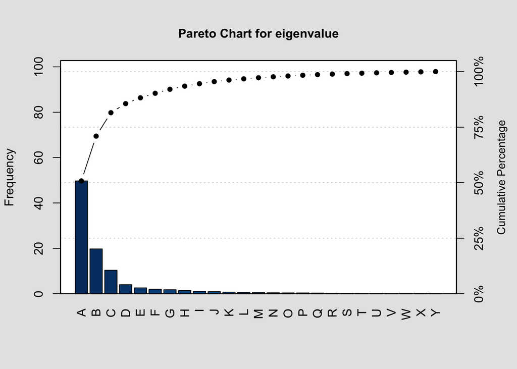

```
##
## Pareto chart analysis for eigenvalue
##       Frequency   Cum.Freq.  Percentage Cum.Percent.
##   A  49.7100000  49.7100000  50.7814894   50.7814894
##   B  19.7500000  69.4600000  20.1757074   70.9571969
##   C  10.3300000  79.7900000  10.5526612   81.5098580
##   D   3.9900000  83.7800000   4.0760037   85.5858617
##   E   2.5700000  86.3500000   2.6253959   88.2112575
##   F   2.0000000  88.3500000   2.0431096   90.2543671
##   G   1.7600000  90.1100000   1.7979365   92.0523036
##   H   1.3800000  91.4900000   1.4097456   93.4620492
##   I   1.0700000  92.5600000   1.0930636   94.5551129
##   J   0.9200000  93.4800000   0.9398304   95.4949433
##   K   0.7000000  94.1800000   0.7150884   96.2100317
##   L   0.5300000  94.7100000   0.5414240   96.7514557
##   M   0.4800000  95.1900000   0.4903463   97.2418020
##   N   0.4200000  95.6100000   0.4290530   97.6708550
##   O   0.3500000  95.9600000   0.3575442   98.0283992
##   P   0.3400000  96.3000000   0.3473286   98.3757279
##   Q   0.2700000  96.5700000   0.2758198   98.6515477
##   R   0.2300000  96.8000000   0.2349576   98.8865053
##   S   0.2100000  97.0100000   0.2145265   99.1010318
##   T   0.1900000  97.2000000   0.1940954   99.2951272
##   U   0.1600000  97.3600000   0.1634488   99.4585760
##   V   0.1500000  97.5100000   0.1532332   99.6118092
##   W   0.1400000  97.6500000   0.1430177   99.7548268
##   X   0.1300000  97.7800000   0.1328021   99.8876290
##   Y   0.1100000  97.8900000   0.1123710  100.0000000
```

```r
library(qcc)
train_data = data.frame()
for (i in 1:fs){
  temp = files[[i]] %>% select(Date, Open)
  colnames(temp)[2] = all_symbols[i]
  if(i > 2) train_data = inner_join(temp, train_data, by = 'Date')
  else train_data = temp
}
train_pca = prcomp(train_data[,2:505], center = T, scale. = T)
eigenvalue = round(train_pca$sdev ^ 2 / sum(train_pca$sdev ^ 2) * 100, 2)
eigenvalue = eigenvalue[1:25]
pareto.chart(eigenvalue)
```

```r
eigenvalue[1] + eigenvalue[2] + eigenvalue[3]
```

```
## [1] 79.79
```

# Q6

متغیرهایی که خطوط نزدیک تری به هم دارند کورلیشن بیشتری با یکدیگر دارند

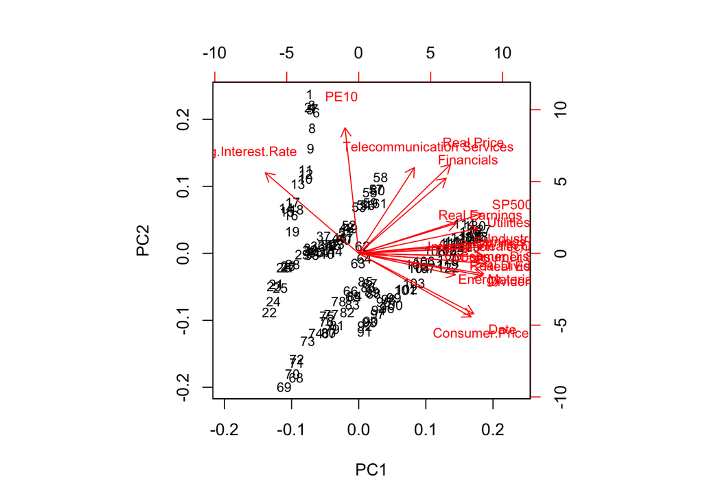

```r
library(reshape2)
all_data = data.frame()
for (i in 1:fs){
    temp = files[[i]] %>% mutate(Symbol = all_symbols[i])
    all_data = rbind(all_data, temp)
}
all_data = all_data %>% select(Symbol, Open, Date) %>% inner_join(constituents, by = 'Symbol') %>% select( Sector, Open, Date) %>% group_by(Sector, Date) %>% summarise(average = mean(Open))
all_data = dcast(all_data, Date ~ Sector)
index = read.csv('class_data/indexes.csv')
index$Date = as.Date(index$Date)
all_data$Date = as.Date(all_data$Date)
all_data = inner_join(all_data, index, by = 'Date')
all_data$Date = as.numeric(all_data$Date)
pca = prcomp(all_data, center = T, scale. = T)
biplot(pca, cex = 0.8)
```

# Q7

با توجه به مقادیر mean square errorها استفاده از مولفه ای اصلی اول به هیچ وجه باعث بهبود مدل نشده است.

```r
aapl = read.csv('class_data/stock_dfs/AAPL.csv')
pca = prcomp(aapl[,2:7], center = T, scale. = T)
first_comp = pca$x[,1]
aapl = aapl %>% mutate(n = c(1:length(Open)))
regression = list()
for (i in 1:k){
  regression = as.data.frame(split(first_comp[1:(cnt - cnt %% i)], 1:i))
  if (i < 2){
    regression = data.frame(cbind(first_comp, aapl$Open))
    print(mean(summary(lm(V2~., data = regression))$residuals ^ 2))

  }
  else{
    cur = aapl %>% filter(n != 1 & n %% i == 1) %>% select(Open)
    if (nrow(regression) > nrow(cur)){
      regression = regression[1:nrow(cur),]
    }
    regression = cbind(regression, cur)
    print(mean(summary(lm(Open~., data = regression))$residuals ^ 2))
  }
}
```

```
## [1] 497.376
## [1] 505.4223
## [1] 504.5382
## [1] 504.4429
## [1] 494.7931
## [1] 500.7586
## [1] 512.2713
## [1] 496.9373
## [1] 503.8765
## [1] 480.3526
## [1] 495.5968
## [1] 501.2966
## [1] 488.4585
## [1] 490.165
## [1] 494.7586
```

# Q8

```r
library(quantmod)
library(h2o)
library(data.table)
sandp500 = as.data.frame(getSymbols('^GSPC', auto.assign = FALSE, from = '2016-01-01'))
```

[output not shown]

[output not shown]

```r
sandp500 = sandp500 %>% setDT(keep.rownames = TRUE)
colnames(sandp500)[1] = c('Date')
sandp500 = sandp500 %>% select(Date, GSPC.Open)
dailyincome = sandp500$GSPC.Open - c(0, sandp500$GSPC.Open[0:(length(sandp500$GSPC.Open) - 1)])
sandp500 = sandp500 %>% mutate(dailyincome = ifelse(dailyincome > 0, 1, 0))
sandp500$Date = as.Date(sandp500$Date)
pca = data.frame(train_pca$x) %>% select(PC1:PC15)
pca$Date = train_data$Date
pca$Date = as.Date(pca$Date)
train_data = sandp500 %>% inner_join(pca, by = 'Date') %>% select(dailyincome, PC1:PC15)
h2o.init()
```

[output not shown]

```r
ht = as.h2o(train_data)
hglm = h2o.glm(y = 'dailyincome', training_frame = ht, family = 'binomial', nfolds = 5)
h2o.confusionMatrix(hglm)
```

```
## Confusion Matrix (vertical: actual; across: predicted)  for max f1 @ threshold = 0.444268525809178:
##         0   1    Error     Rate
## 0      19  33 0.634615   =33/52
## 1       3  71 0.040541    =3/74
## Totals 22 104 0.285714  =36/126
```

# Q9

حجم عکس ها تا جایی در حال افزایش است و پس از آن کاهش می یابد. اما قبل از نقطه ی ماکسیموم کیفیت عکس ها بسیار پایین است. پس به نظر میرسد استفاده از تمام مولفه ها بهتر باشد.

```r
library(EBImage)
library(jpeg)
image = flip(readImage('stock.jpg'))
parameters = 412;
blue = image[,,3]
green = image[,,2]
red = image[,,1]
bluecomp = prcomp(blue, center = FALSE)
greencomp = prcomp(green, center = FALSE)
redcomp = prcomp(red, center = FALSE)
all_size = c()
color_list = list(redcomp, greencomp, bluecomp)
for (i in 1:parameters){
  writeJPEG(sapply(color_list, function(N){current = N$x[,1:i] %*% t(N$rotation[,1:i])},
                   simplify = 'array'), paste('~/HW9_94109324/Problem9/', i, '.', 'jpg', sep = ''))
}
for (i in 1:parameters){
  image_address = paste('~/HW9_94109324/Problem9/', i, '.', 'jpg', sep = '')
  image_size = file.info(image_address)$size / 1000
  all_size = c(all_size, image_size)
}
all_size = data.frame(all_size)
all_size = cbind(1:parameters, all_size)
colnames(all_size) = c('ID', 'image_size')
hchart(all_size, 'line', hcaes(x = ID ,y = image_size)) %>% hc_add_theme(hc_theme_monokai())
```

[interactive chart not shown]

# Q10

بررسی سقوط و صعود شرکت ها در هر بخش. آیا بخش هایی بوده اند که در طی سال ها با افت سهام به طور کلی مواجه شوند. بررسی بیشترین نرخ صعود سهام به طور کلی و بررسی علل آن. بررسی تاثیر بحران های خاورمیانه در سهام آمریکا به خصوص جنگ با عراق. بررسی تغییرات سهام شرکت های بزرگ کامپیوتری مانند فیس بوک گوگل و اپل